# Midterm Exam Take-Home Portion (90 points)

Olivia Martin

2022-10-19

**Instructions.** This will become available after class on Tuesday, October 11, will be completed outside of class, and will be due Wednesday, October 19, 5:00pm. You may use the text, your notes, posted class files, Excel, R, and RStudio. No communication is permitted with anyone other than the instructor. Upload the completed Rmd file and a knitted file to Moodle.

**Exercise 1 (62 points).** Consider the `ChickWeight` data set that is built into base R. Notice from the code book, `weight` and `Time` are quantitative variables while `Chick` and `Diet` are categorical variables.

1. (10 points) Create a tibble `chicks` that contains the data from`ChickWeight`with the following changes: (i) `weight` is renamed `Mass`, (ii) `Diet` becomes a factor variable, (iii) the `Chick` variable is removed, and (iv) a new variable `weeks` contains the time in units of weeks. Obtain the five cases of `chicks` with the largest mass.

   ```r
   chicks = ChickWeight %>% transmute(mass = weight, time = Time, diet = as.factor(Diet), weeks = floor(Time/7))
   ```

2. (10 points) Obtain the linear model `Mass ~ Time - 1`. Explicitly state the best fit formula. Interpret the single coefficient. State the residual standard error (with units) and the proportion of the variation in mass that is explained by the model.

   ```r
   chickmodel1 = lm(mass ~ time - 1, chicks)
   summary(chickmodel1)
   ```

   ```
   ##
   ## Call:
   ## lm(formula = mass ~ time - 1, data = chicks)
   ##
   ## Residuals:
   ##     Min      1Q  Median      3Q     Max
   ## -149.39  -10.93   14.17   28.73  149.61
   ##
   ## Coefficients:
   ##      Estimate Std. Error t value Pr(>|t|)
   ## time  10.6376     0.1364   77.97   <2e-16 ***
   ## ---
   ## Signif. codes:  0 '***' 0.001 '**' 0.01 '*' 0.05 '.' 0.1 ' ' 1
   ##
   ## Residual standard error: 41.55 on 577 degrees of freedom
   ## Multiple R-squared:  0.9133, Adjusted R-squared:  0.9132
   ## F-statistic:  6080 on 1 and 577 DF,  p-value: < 2.2e-16
   ```

   The best fit formula is mass (g) = 10.63 * time (days), meaning that a chick grows by 10.63 grams every day. The RSE is 41.55 grams and 91.32% of the variation in mass is explained by this model.
3. (10 points) Obtain the linear model `Mass ~ Diet:Time - 1`. Interpret the obtained coefficients. State the residual standard error (with units) and the proportion of the variation in mass that is explained by the model.

   ```r
   chickmodel2 = lm(mass ~ diet:time - 1, chicks)
   summary(chickmodel2)
   ```

   ```
   ##
   ## Call:
   ## lm(formula = mass ~ diet:time - 1, data = chicks)
   ##
   ## Residuals:
   ##      Min       1Q   Median       3Q      Max
   ## -146.555   -9.252   12.204   28.847  117.953
   ##
   ## Coefficients:
   ##            Estimate Std. Error t value Pr(>|t|)
   ## diet1:time   8.9296     0.2011   44.41   <2e-16 ***
   ## diet2:time  10.5026     0.2641   39.77   <2e-16 ***
   ## diet3:time  12.6297     0.2641   47.83   <2e-16 ***
   ## diet4:time  11.7743     0.2699   43.63   <2e-16 ***
   ## ---
   ## Signif. codes:  0 '***' 0.001 '**' 0.01 '*' 0.05 '.' 0.1 ' ' 1
   ##
   ## Residual standard error: 37.17 on 574 degrees of freedom
   ## Multiple R-squared:  0.931,  Adjusted R-squared:  0.9305
   ## F-statistic:  1936 on 4 and 574 DF,  p-value: < 2.2e-16
   ```

   According to this model, chicks on diet 1 gain about 8.9 grams per day, chicks on diet 2 gain about 10.5 grams per day, chicks on diet 3 gain about 12.6 grams per day, and chicks on diet 4 gain about 11.8 grams per day.

   The RSE is 37.17 grams and 93.05% of the variation in mass is explained by this model.
4. (10 points) Obtain a scatter plot of `Mass` vs. `Time` grouped by `Diet` (use color or shape to display the groups) with lines showing the model obtained in part (c). Include appropriate labels for the axes.

[figure not shown]

   ```r
   chicks %>% ggplot(aes(x = time, y = mass, color = diet)) +
     geom_point(alpha = 0.6) +
     geom_lm() +
     scale_color_viridis(discrete = TRUE) +
     xlab('mass (g)') +
     ylab('time (days)')
   ```

5. (2 points) Based on this data, which diet would be best for a chicken farmer?

   Allow me to depart from the data for a moment and point out that it seems rather impossible to determine what is best based on weight alone. We don’t know the cost of any of these feeds per chick per day, or if the feed type affects mean quality. It doesn’t matter how much meat is on the bird if none of it is particularly good.

   That said, according to `chickmodel2`, diet 3 offers the highest rate of change for chicks’ mass. If the goal is to increase the chicks’ mass as fast as possible, then diet 3 would accomplish that task most effectively. However, since we haven’t learned how to do f-tests yet, I can’t say for sure if diet actually has a clear impact on mass. Since the values of R-squared are so close, it’s just really hard to say if it matters at all.
6. (10 points) Obtain the sample size, mean, standard deviation, and 95% coverage interval mass for the chicks at 10 days. In addition to the computation, state your answers in a sentence with appropriate precision and units.

   ```r
   chicks10 = chicks %>% filter(time == 10)
   chicks10 %>% summarise(n = n(), mean = mean(mass), sd = sd(mass), lower = quantile(mass, 0.025), upper = quantile(mass, 0.975))
   ```

   | n | mean | sd | lower | upper |
   | --- | --- | --- | --- | --- |
   | 49 | 107.8367 | 23.98728 | 67.2 | 157.8 |

   ```r
   rmean = function(n0) {
     chicks10 %>%
       slice_sample(n = n0, replace = TRUE) %>%
       summarise(mean = mean(mass))
   }

   x = tibble(mean = NULL)
   for (i in 1:1000) {
     x = bind_rows(x, rmean(200))
   }
   x %>% summarise(quantile(mean, 0.025), quantile(mean, 0.975))
   ```

   | quantile(mean, 0.025) | quantile(mean, 0.975) |
   | --- | --- |
   | 104.3049 | 111.0161 |

**Exercise 2 (25 points).** Each row in *HousmanGrades.csv* file corresponds to a student taking a course from David Housman at Goshen College. Students who received CR, NC, or I grades were excluded. Some students took more than one course from David Housman and so appear in multiple rows. The *Course* column contains an identifier for the course (e.g., ‘MA321’ is Math 321 Differential Equations). The *Time* column contains an identifier for the term in which the course was taken (e.g., ‘2016-2017 Fall’ is the Fall semester of the 2016-2017 academic year, and ‘1998 MIS-98L’ is a special term for a cohort of degree completion students). The *Grade* column contains the letter grade received by the student in the given course during the given term.

1. (4 points) Read the data from the file into a data frame or tibble. How many student-course cases are in the data set?

   ```r
   HousmanGrades <- read.csv("~/Desktop/HousmanGrades.csv")
   nrow(HousmanGrades)
   ```

   ```
   ## [1] 2264
   ```

2. (2 points) Obtain the number of different courses that David Housman has taught at Goshen College (for which at least one student received a standard letter grade).

   ```r
   unique(HousmanGrades$Course) %>% length()
   ```

   ```
   ## [1] 54
   ```

3. (4 points) Obtain the absolute and relative frequencies of the courses of the five most taken courses.

   ```r
   HousmanGrades %>% count(Course) %>% slice_max(n, n = 5) %>% mutate(rel = round(n/2264, 2))
   ```

   | Course | n | rel |
   | --- | --- | --- |
   | MA105 | 358 | 0.16 |
   | CS200 | 238 | 0.11 |
   | MA321 | 189 | 0.08 |
   | MA211 | 138 | 0.06 |
   | MA323 | 115 | 0.05 |

4. (6 points) Obtain a bar chart of the frequency of each grade given by David Housman. For full credit, the letter grades should appear in the best-to-worst order A, A-, B+, B, B-, C+, C, C-, D+, D, F. One approach to accomplish this is to use the `factor` command inside a `mutate` command. The point of this exercise is to see if you can figure out how to do this by reading the documentation (the “help” tab in RStudio)

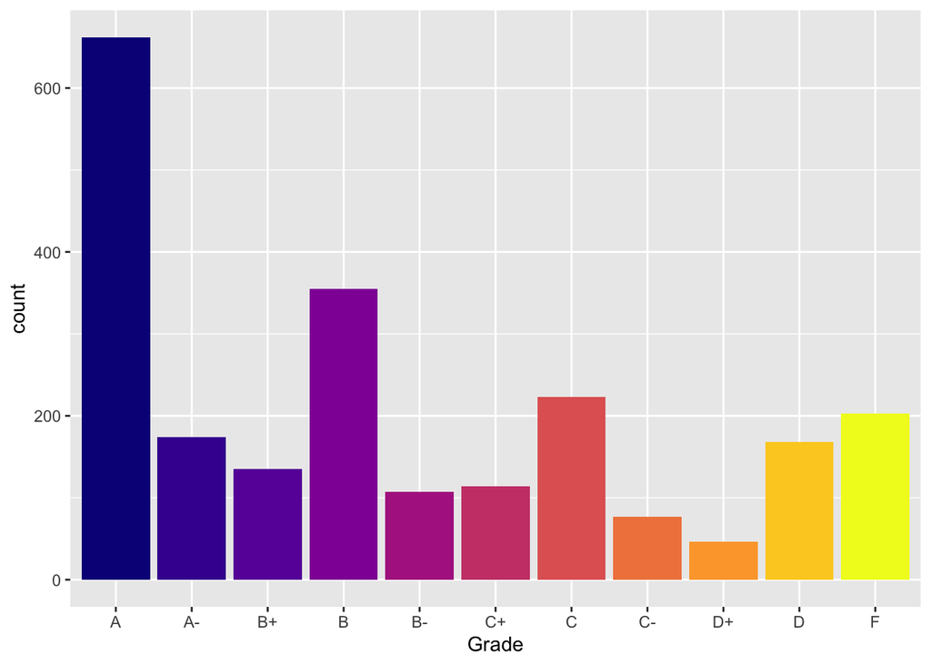

   ```r
   grade_order = c('A','A-','B+','B','B-','C+','C','C-','D+','D','F')
   HousmanGrades %>% mutate(Grade = ordered(HousmanGrades$Grade, levels = grade_order)) %>% ggplot(aes(x = Grade, fill = Grade)) +
     geom_bar(show.legend = FALSE) +
     scale_fill_viridis(discrete = TRUE, option = 'plasma')
   ```

5. (3 points) Create a new column *QPts* that recodes letter grades by their equivalent quality points: ‘A’ becomes 4.0, ‘A-’ becomes 3.7, ‘B+’ becomes 3.3, and so forth.

   ```r
   HousmanGrades %>% mutate(QPts = recode_factor(HousmanGrades$Grade, 'A' = 4.0, 'A-' = 3.7, 'B+' = 3.3, 'B' = 3.0, 'B-' = 2.7, 'C+' = 2.3, 'C' = 2.0, 'C-' = 1.7, 'D+' = 1.3, 'D' = 1.0, 'F' = 0))
   ```

   | Course | Time | Grade | QPts |
   | --- | --- | --- | --- |
   | MIS200 | 1998 MIS-98L | A | 4 |
   | MIS200 | 1998 MIS-98L | A | 4 |
   | MIS200 | 1998 MIS-98L | B | 3 |
   | MIS200 | 1998 MIS-98L | B | 3 |
   | MIS200 | 1998 MIS-98L | C | 2 |
   | MIS200 | 1998 MIS-98L | C | 2 |
   | MIS200 | 1998 MIS-98L | F | 0 |
   | MIS200 | 1998 MIS-98M | A | 4 |
   | MIS200 | 1998 MIS-98M | A | 4 |
   | MIS200 | 1998 MIS-98M | A | 4 |

   [output cut: 2254 more lines]

6. (3 points) Obtain a density plot of quality points.

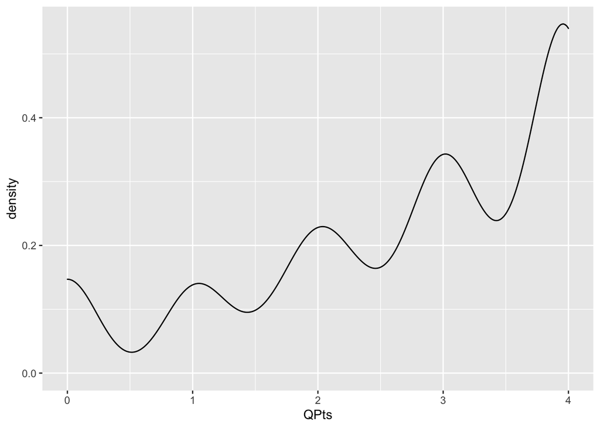

   ```r
   HousmanGrades %>% mutate(QPts = recode(HousmanGrades$Grade, 'A' = 4.0, 'A-' = 3.7, 'B+' = 3.3, 'B' = 3.0, 'B-' = 2.7, 'C+' = 2.3, 'C' = 2.0, 'C-' = 1.7, 'D+' = 1.3, 'D' = 1.0, 'F' = 0)) %>% ggplot(aes(x = QPts)) +
     geom_density()
   ```

7. (3 points) In what way(s) are the graphs in parts (f) and (d) similar to and different from a normal distribution?

   They’re similar in that there appears to be a bell curve-esque shape covering each letter except F (i.e., one going from C+ to C- and centered at C), but different in that there are multiple such curves across the data whereas in a normal distribution we would expect only one. Each separate curve also seems to be skewed, mostly toward the positive.

**Exercise 3 (3 points).** Both an Rmd file and a knitted file (doc, pdf, or html) is uploaded in Moodle.